# **Foundations of Machine Learning:**

#### **Scatterplot Histograms**

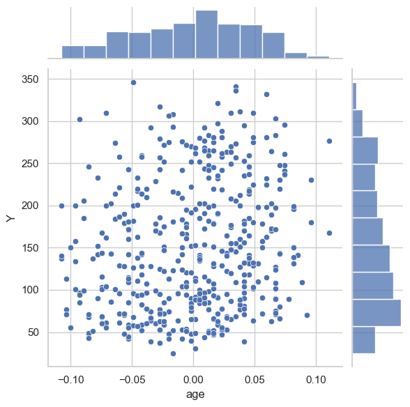

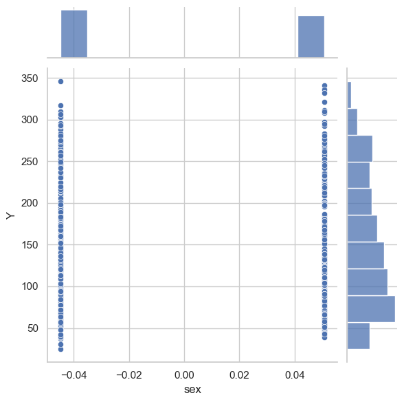

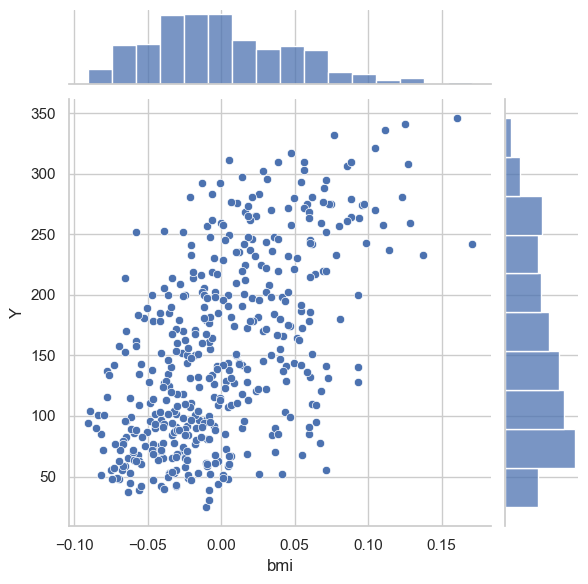

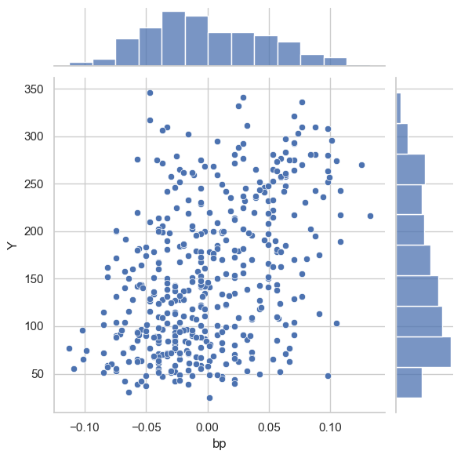

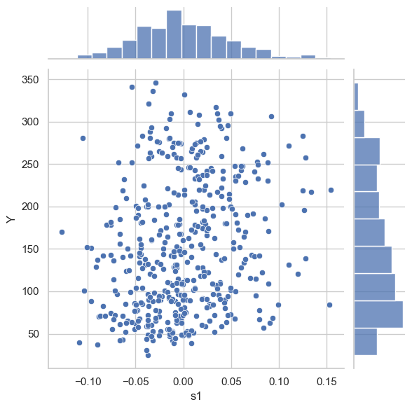

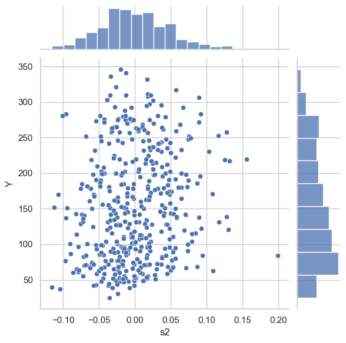

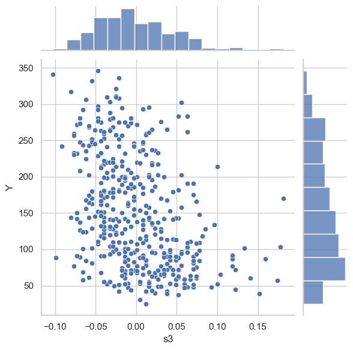

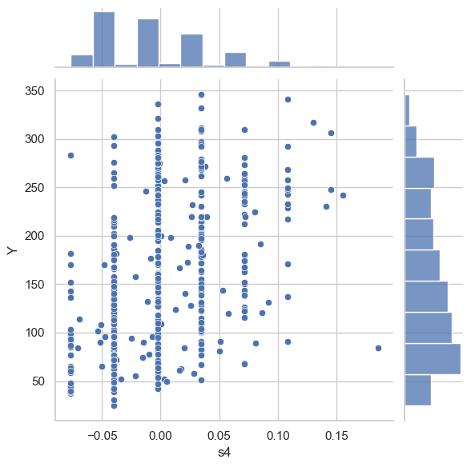

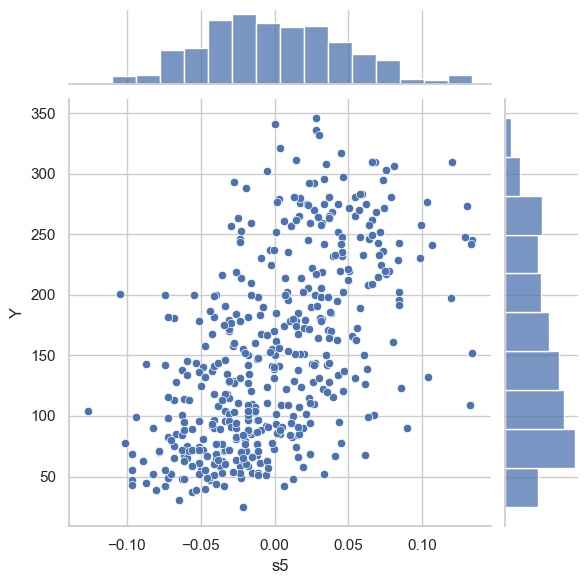

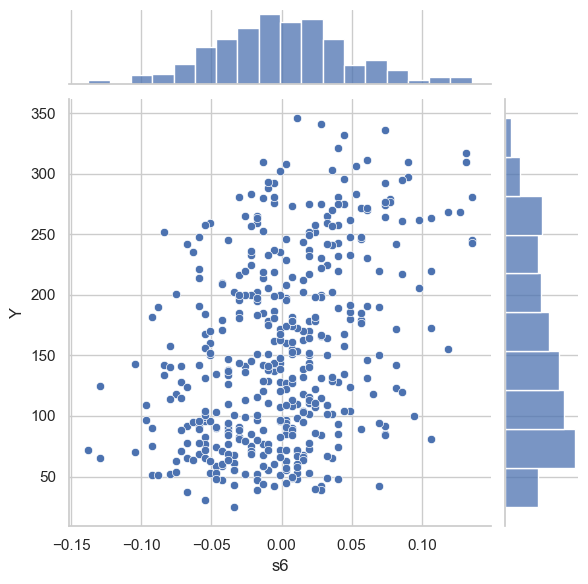

```python
sns.set(style="whitegrid", color_codes=True)
for feature in diabetes.columns:
    if feature != "Y": # we want y to be in Y axis so not including a Y to be in both axis, chart
        sns.jointplot(x=feature, y="Y", data=diabetes)
        plt.show()
```

**Highlights in the distribution:**

**bmi:** There are more individuals with lower BMI values, but a tail extends toward higher values.

**S4** shows multiple peaks, suggesting possible multimodal distribution or categorical influences.

The output variable **'Y'** displays a significant right-skewed distribution, implying a concentration of lower values with fewer extreme high values.

Correlation Heatmap

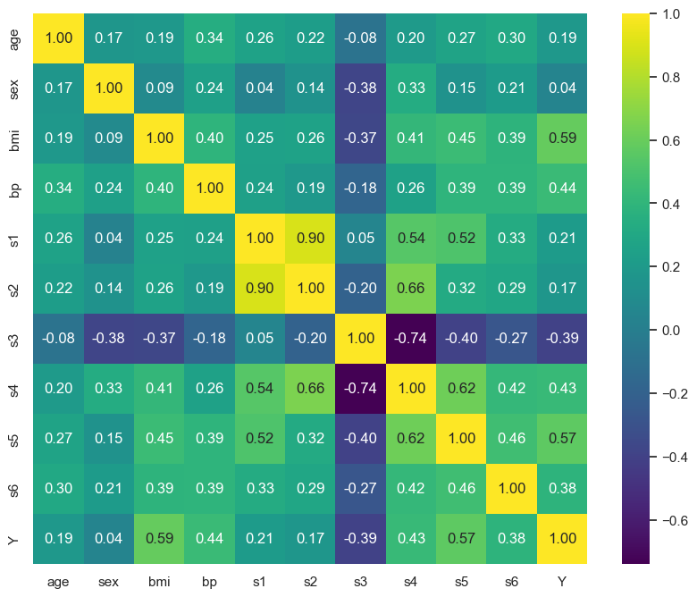

```python
plt.figure(figsize=(10,8))
sns.heatmap(diabetes.corr(), annot=True, cmap='viridis', fmt='.2f')
plt.show()
```

**Observing Correlations:**

s1: with s2 has a correlation coeff of 0.9 indicating a high positive correlation

s4: with s5 has a 0.62 indicating a moderately high positive correlation.

s3: with s4 has a - 0.74 indicating a moderately high negative correlation.

s3 is mostly having negative correlations with other variables

most of the features: s1 to s6 share a significant correlation coeff between them.

s5 and Y have a correlation coeff of 0.57 while bmi and Y have 0.59 indicating that these two are the most signifcant variables in determining output variable **'Y'**

### **4. Data Preprocessing**

Cleaning the data / dropping unnecessary data

```python
diabetes = diabetes.drop(columns=['sex'])
```

I dropped the 'sex' column because it doesn't contribute much in determining our target variable 'Y' with a correlation coeff of 0.04. This means that it doesn't matter whether the person is male or female when it comes to determining the disease progression in 1 year

### **5.Train validation and test split**

```python
train_size = int(len(diabetes) * 0.75)
val_size = int(len(diabetes) * 0.10)

train_data = diabetes[:train_size]
val_data = diabetes[train_size:train_size + val_size]
test_data = diabetes[train_size + val_size:]
```

## **PART 2**

### **6. Model Deployment**

```python
def create_polynomial_model(degree, X_train, y_train, X_val, y_val):
    poly = PolynomialFeatures(degree=degree)
    X_train_poly = poly.fit_transform(X_train)
    X_val_poly = poly.transform(X_val)

    model = LinearRegression()
    model.fit(X_train_poly, y_train)

    y_train_pred = model.predict(X_train_poly)
    y_val_pred = model.predict(X_val_poly)

    res = {
        "Degree": degree,
        "Train R2": r2_score(y_train, y_train_pred),
        "Validation R2": r2_score(y_val, y_val_pred),
        "Train MAE": mean_absolute_error(y_train, y_train_pred),
        "Validation MAE": mean_absolute_error(y_val, y_val_pred),
        "Train MAPE": mean_absolute_percentage_error(y_train, y_train_pred),
        "Validation MAPE": mean_absolute_percentage_error(y_val, y_val_pred),
    }

    return model, poly, res
```

```python
def train_multiple_models(X_train, y_train, X_val, y_val, degrees):
    models = {}
    results = []

    for deg in degrees:
        model, poly, res = create_polynomial_model(degree=deg, X_train=X_train, y_train=y_train, X_val=X_val, y_val=y_val)
        models[deg] = (model, poly)
        results.append(res)
    return models, pd.DataFrame(results)

bmi_train = train_data[['bmi']]
bmi_val = val_data[['bmi']]
bmi_test = test_data[['bmi']]

y_train = train_data['Y']
y_val = val_data['Y']
y_test = test_data['Y']

models, results_df = train_multiple_models(bmi_train, y_train, bmi_val, y_val, range(0,6))
results_df.set_index('Degree', inplace=True)
```

### **7. Model Evaluation**

```python
results_df
```

| Degree | Train R2 | Validation R2 | Train MAE | Validation MAE | Train MAPE | Validation MAPE |
| --- | --- | --- | --- | --- | --- | --- |
| 0 | 0.000000 | -0.035692 | 64.736339 | 68.838025 | 0.613073 | 0.525862 |
| 1 | 0.324504 | 0.442344 | 52.100347 | 48.799466 | 0.481194 | 0.351988 |
| 2 | 0.327573 | 0.408676 | 51.809102 | 49.808875 | 0.478417 | 0.355012 |
| 3 | 0.327586 | 0.412079 | 51.796375 | 49.676010 | 0.478171 | 0.354091 |
| 4 | 0.330671 | 0.339617 | 51.671484 | 51.777645 | 0.475888 | 0.359416 |
| 5 | 0.331279 | 0.376086 | 51.660339 | 51.051367 | 0.475954 | 0.357207 |

- **Degree 1** has the highest validation **R2 (0.442344)**, which shows it performs best on unseen data compared to others. Its validation **MAE** and **MAPE** are also the lowest compared to other models.
- **Degree 2** and **Degree 3** models show similar performance with **R2** values of around **0.40-0.41** for validation, but their **MAE** and **MAPE** values are a little higher than **Degree 1**.
- **Degree 4** and **Degree 5** show a significant drop in validation **R2**, and their **MAE** and **MAPE** values are higher than those of **Degree 1** and **Degree 2**, suggesting these higher-degree models may be overfitting the training data and not generalizing well.

### **8. Model Selection**

I will select **Degree 1** as the best model, because:

It has the highest validation **R2**, indicating it generalizes better.

It has the lowest validation **MAE** and **MAPE**, meaning the predictions are more accurate on unseen data.

### **9.Running test on Chosen Best Model**

```python
def test_model(X_train, y_train, X_test, y_test, degree):
    model, poly, _ = create_polynomial_model(degree, X_train, y_train, X_test, y_test)

    X_test_poly = poly.transform(X_test)
    y_test_pred = model.predict(X_test_poly)

    test_r2 = r2_score(y_test, y_test_pred)
    test_mae = mean_absolute_error(y_test, y_test_pred)
    test_mape = mean_absolute_percentage_error(y_test, y_test_pred)

    results_df = pd.DataFrame({
        "Degree": [degree],
        "Test R2": [test_r2],
        "Test MAE": [test_mae],
        "Test MAPE": [test_mape]
    })

    return results_df


best_degree = 1
test_results_df = test_model(bmi_train, y_train, bmi_test, y_test, best_degree)

test_results_df.set_index('Degree', inplace=True)

test_results_df
```

| Degree | Test R2 | Test MAE | Test MAPE |
| --- | --- | --- | --- |
| 1 | 0.354414 | 52.345039 | 0.525044 |

### **10. Plotting the Graph of Train, Validation, and Test Data with the Fit of the Chosen Model**

```python
def plot_model(X_train, y_train, X_val, y_val, X_test, y_test, model, poly, degree):
    plt.figure(figsize=(10, 6))

    plt.scatter(X_train, y_train, color='blue', label='Train Data', alpha=0.5)
    plt.scatter(X_val, y_val, color='orange', label='Validation Data', alpha=0.5)
    plt.scatter(X_test, y_test, color='green', label='Test Data', alpha=0.5)

    x_range = np.linspace(X_train.min(), X_train.max(), 100).reshape(-1, 1)
    x_range_poly = poly.transform(x_range)
    y_range_pred = model.predict(x_range_poly)

    plt.plot(x_range, y_range_pred, color='red', label=f'Best Fit Line', lw=2)

    plt.title(f'Train, Validation, and Test Data with Best Fit Line (Degree {degree})', fontsize=14)
    plt.xlabel('BMI', fontsize=12)
    plt.ylabel('Disease Progression', fontsize=12)
    plt.legend()
    plt.grid(True)
    plt.show()
```

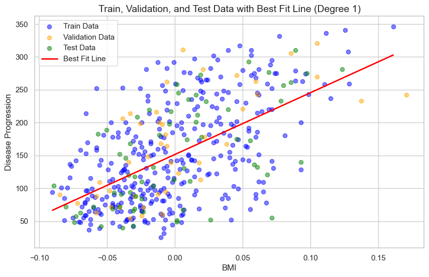

```python
best_degree = 1

model, poly, _ = create_polynomial_model(best_degree, bmi_train, y_train, bmi_val, y_val)

plot_model(bmi_train, y_train, bmi_val, y_val, bmi_test, y_test, model, poly, best_degree)
```

### **11. Writing the Equation of the Best Model (Degree 1)**

Since we selected a univariate polynomial regression model with degree 1, the equation of the best model will be a linear equation of the form:

**y = β<sub>0</sub> + β<sub>1</sub> ⋅ BMI**

Where:

- **β<sub>0</sub>** is the intercept
- **β<sub>1</sub>** is the coefficient of the BMI feature

```python
intercept = model.intercept_
coefficient = model.coef_[1]

print(f"Model Equation for the best model ( Degree = 1 ): \n\ny = {intercept:.2f} + {coefficient:.2f} * BMI")
```

```
Model Equation for the best model ( Degree = 1 ):

y = 151.49 + 941.47 * BMI
```

### **12. Calculate the Expected Diabetes Progression for a BMI Value of Your Choice**

```python
bmi_value = 0.02422
bmi_value_poly = poly.transform([[bmi_value]])

predicted_progression = model.predict(bmi_value_poly)
print(f"Expected Diabetes Progression after 1 year for BMI = {bmi_value}: {predicted_progression[0]:.2f}")
```

```
Expected Diabetes Progression after 1 year for BMI = 0.02422: 174.29
```

### **13. Count Trainable Parameters in the Model**

```python
features = poly.get_feature_names_out(input_features=['bmi'])
print(f"Number of Trainable Parameters: {len(features)}")
print(f"Trainable Parameters: {features}")
```

```
Number of Trainable Parameters: 2
Trainable Parameters: ['1' 'bmi']
```

- 1: constant feature for the intercept (bias term)
- bmi: original feature
- bmi^2: squared term
- bmi^3: cubic term

and so on for every feature ( in this case we only have 1 feature =bmi, but in part 3 we will have much more)

### **14. Conclusion:**

### **14. Conclusion**

The **Degree 1** Polynomial Regression model was selected for predicting diabetes progression. Its performance is moderate, with a **Test R² of 0.354** indicating a fair fit, but there is room for improvement in generalizing to unseen data. The **Predicted Diabetes Progression after 1 year** is 174.29, based on the given features [bmi = 0.02422].

#### **Model Performance Summary**

- **Train R²**: 0.324504 (Moderate fit on training data)
- **Validation R²**: 0.442344 (Moderate fit on validation data)
- **Test R²**: 0.354414 (Fair fit on test data)
- **Train MAE**: 52.100347 (Moderate error on training set)
- **Validation MAE**: 48.799466 (Moderate error on validation set)
- **Test MAE**: 52.345039 (Moderate error on test set)
- **Train MAPE**: 0.481194 (Moderate percentage error on training set)
- **Validation MAPE**: 0.351988 (Moderate percentage error on validation set)
- **Test MAPE**: 0.525044 (Indicating moderate percentage error on the test set)

#### **Model Limitations**

- **Limited Predictive Power**: While the model shows a decent fit on the training and validation sets, the R² value on the test set is still moderate, indicating that it doesn't fully capture the complexities of diabetes progression based solely on BMI.
- **Single Predictor**: The model uses only BMI as the predictor, which may not capture all relevant factors influencing diabetes progression. Including more features could improve performance.
- **Potential for Improvement**: Despite its simplicity, a higher-degree polynomial or more complex models may be necessary to capture non-linear relationships and improve predictive accuracy.

## **PART 3**

```python
selected_features = ["age", "bmi", "bp", "s1", "s3", "s4", "s5","s6"]

X_train_selected = train_data[selected_features]
X_val_selected = val_data[selected_features]
X_test_selected = test_data[selected_features]

y_train = train_data["Y"]
y_val = val_data["Y"]
y_test = test_data["Y"]
```

## **Polynomial Regression For Degrees = 3,5 (My Choice)**

### Model Training and testing

```python
models, Polynomial_train_results = train_multiple_models(X_train_selected, y_train, X_val_selected, y_val, [3, 5])

Polynomial_test_results = test_model(X_train_selected, y_train, X_test_selected, y_test, 3)

Polynomial_train_results.set_index('Degree', inplace=True)
Polynomial_test_results.set_index('Degree', inplace=True)
```

Train result

```python
Polynomial_train_results
```

| Degree | Train R2 | Validation R2 | Train MAE | Validation MAE | Train MAPE | Validation MAPE |
| --- | --- | --- | --- | --- | --- | --- |
| 3 | 0.740487 | -1.347550 | 3.023196e+01 | 84.557764 | 2.764802e-01 | 0.566242 |
| 5 | 1.000000 | -36.652098 | 1.815808e-11 | 314.701982 | 1.608510e-13 | 2.208232 |

The Degree 3 model is better. The Degree 5 model is completely overfitting, while Degree 3, although not perfect, generalizes far better to validation data.

9. Test Result

```python
Polynomial_test_results
```

| Degree | Test R2 | Test MAE | Test MAPE |
| --- | --- | --- | --- |
| 3 | -0.862158 | 77.517957 | 0.721468 |

```python
# no 10th step required here:

model, poly, _ = create_polynomial_model(3, X_train_selected, y_train, X_val_selected, y_val)

# 11
equation = f"y = {model.intercept_:.2f}"
for i, feature in enumerate(selected_features):
    equation += f" + ({model.coef_[i]:.2f}) * {feature}"

print(f"11. Model Equation for Degree 3: \n{equation}")
```

```
11. Model Equation for Degree 3:
y = 147.02 + (0.00) * age + (24.59) * bmi + (355.57) * bp + (655.32) * s1 + (-1206.67) * s3 + (1010.65) * s4 + (1143.39) * s5 + (545.45) * s6
```

```python
# 12 for given feature values = bmi, age, bp, s1, s3, s4, s5,

Predicted_feature_values = [0.038076, 0.050680, 0.021872, -0.044223, -0.043401, -0.002592, 0.019907, -0.017646]

poly_features = poly.transform([Predicted_feature_values])  # Keep as a single list inside []

predicted_progression = model.predict(poly_features)

print(f"\n12. Expected Diabetes Progression for the given features:\n"
      f"bmi = {Predicted_feature_values[0]:.3f},\n"
      f"age = {Predicted_feature_values[1]:.3f},\n"
      f"bp = {Predicted_feature_values[2]:.3f},\n"
      f"s1 = {Predicted_feature_values[3]:.3f},\n"
      f"s3 = {Predicted_feature_values[4]:.3f},\n"
      f"s4 = {Predicted_feature_values[5]:.3f},\n"
      f"s5 = {Predicted_feature_values[6]:.3f},\n"
      f"s6 = {Predicted_feature_values[7]:.3f},\n"
      f"s6 = {Predicted_feature_values[7]:.3f},\n"
      f"Predicted Diabetes Progression after 1 year = {predicted_progression[0]:.2f}")
```

```
12. Expected Diabetes Progression for the given features:
bmi = 0.038,
age = 0.051,
bp = 0.022,
s1 = -0.044,
s3 = -0.043,
s4 = -0.003,
s5 = 0.020,
s6 = -0.018,
s6 = -0.018,
Predicted Diabetes Progression after 1 year = 212.53
```

```python
#13.
features = poly.get_feature_names_out(input_features=selected_features)
print(f"\n13.Number of Trainable Parameters: {len(features)}")
print(f"\nTrainable Parameters: {features}")
```

```
13.Number of Trainable Parameters: 165

Trainable Parameters: ['1' 'age' 'bmi' 'bp' 's1' 's3' 's4' 's5' 's6' 'age^2' 'age bmi' 'age bp'
 'age s1' 'age s3' 'age s4' 'age s5' 'age s6' 'bmi^2' 'bmi bp' 'bmi s1'
 'bmi s3' 'bmi s4' 'bmi s5' 'bmi s6' 'bp^2' 'bp s1' 'bp s3' 'bp s4'
 'bp s5' 'bp s6' 's1^2' 's1 s3' 's1 s4' 's1 s5' 's1 s6' 's3^2' 's3 s4'
 's3 s5' 's3 s6' 's4^2' 's4 s5' 's4 s6' 's5^2' 's5 s6' 's6^2' 'age^3'
 'age^2 bmi' 'age^2 bp' 'age^2 s1' 'age^2 s3' 'age^2 s4' 'age^2 s5'
 'age^2 s6' 'age bmi^2' 'age bmi bp' 'age bmi s1' 'age bmi s3'
 'age bmi s4' 'age bmi s5' 'age bmi s6' 'age bp^2' 'age bp s1' 'age bp s3'
 'age bp s4' 'age bp s5' 'age bp s6' 'age s1^2' 'age s1 s3' 'age s1 s4'
 'age s1 s5' 'age s1 s6' 'age s3^2' 'age s3 s4' 'age s3 s5' 'age s3 s6'
 'age s4^2' 'age s4 s5' 'age s4 s6' 'age s5^2' 'age s5 s6' 'age s6^2'
 'bmi^3' 'bmi^2 bp' 'bmi^2 s1' 'bmi^2 s3' 'bmi^2 s4' 'bmi^2 s5' 'bmi^2 s6'
 'bmi bp^2' 'bmi bp s1' 'bmi bp s3' 'bmi bp s4' 'bmi bp s5' 'bmi bp s6'
 'bmi s1^2' 'bmi s1 s3' 'bmi s1 s4' 'bmi s1 s5' 'bmi s1 s6' 'bmi s3^2'
 'bmi s3 s4' 'bmi s3 s5' 'bmi s3 s6' 'bmi s4^2' 'bmi s4 s5' 'bmi s4 s6'
 'bmi s5^2' 'bmi s5 s6' 'bmi s6^2' 'bp^3' 'bp^2 s1' 'bp^2 s3' 'bp^2 s4'
 'bp^2 s5' 'bp^2 s6' 'bp s1^2' 'bp s1 s3' 'bp s1 s4' 'bp s1 s5' 'bp s1 s6'
 'bp s3^2' 'bp s3 s4' 'bp s3 s5' 'bp s3 s6' 'bp s4^2' 'bp s4 s5'
 'bp s4 s6' 'bp s5^2' 'bp s5 s6' 'bp s6^2' 's1^3' 's1^2 s3' 's1^2 s4'
 's1^2 s5' 's1^2 s6' 's1 s3^2' 's1 s3 s4' 's1 s3 s5' 's1 s3 s6' 's1 s4^2'
 's1 s4 s5' 's1 s4 s6' 's1 s5^2' 's1 s5 s6' 's1 s6^2' 's3^3' 's3^2 s4'
 's3^2 s5' 's3^2 s6' 's3 s4^2' 's3 s4 s5' 's3 s4 s6' 's3 s5^2' 's3 s5 s6'
 's3 s6^2' 's4^3' 's4^2 s5' 's4^2 s6' 's4 s5^2' 's4 s5 s6' 's4 s6^2'
 's5^3' 's5^2 s6' 's5 s6^2' 's6^3']
```